```python
# Run this cell first!
from datascience import *
import pandas as pd
import numpy as np
%matplotlib inline
import matplotlib.pyplot as plt
import seaborn as sns
```

# Modelling Monthly Adjusted Paid Claims Weighting for Renewal Projections

The basis for this project is to create a model for the weights of each month's adjusted paid claims values (1-36) when calculating renewal rates for Huntington Medical Group. It is important to note that this model will generally be relaible only for this particular client. In a further analysis, we can look at whether this model can potentially be generalizable across other similar clients.

## Background

For this project, the main focus will be on employer-sponsored health insurance renewals and using monthly Adjusted Paid Claims data to help us predict renewal rates. Our data will be the complete historical set of C&E reports for Huntington Hospital starting in 2015. We'll be using this to essentially create a model that determines how much we should weight each months' Adjusted Paid Claims values when predicting the yearly Adjusted Paid Claims value for the following year. Specifically, we've been tasked to find weights for the previous 36 months (e.g. 3 years).

### Basic Methodology

Since our goal is to predict annual renewal rate increases, the granularity of the data will be yearly (i.e. each row will represent a **Renewal Year** and not a standard year). However, because Huntington Medical Group has data going back only to 2015, this doesn't give us many data points to use to train our model. To remedy this, we'll want to try and bootstrap the existing data to reconstruct the population from our sample and use the reconstructed population to train our model. *It is essential to note, however, that this method only works if the sample we are using to reconstruct the population is a representative sample.* Let's perform some EDA on the data to break this down.

## Exploratory Data Analysis

### Data

We have an initial dataset to use. Let's load it in and perform some EDA on it to determine whether our bootstrapping method is appropriate. This data was generated from Huntington Medical Group's historical Monthly C&E Reports.

```python
claims = pd.read_csv('Huntington Medical Paid Claims Data.csv')
claims
```

|  | Month | Year | Renewal Year | Domestic Medical Claims | Non-Domestic Medical Claims | Total Hospital Medical Claims | Non-Hospital Medical Claims | Total Medical Claims | Rx Claims | Rx Rebates | Rx Performance Guarantee | Stop Loss Reimbursement | Adjusted Paid Claims | Member Count | EE Count |
| --- | --- | --- | --- | --- | --- | --- | --- | --- | --- | --- | --- | --- | --- | --- | --- |
| 0 | 1 | 2015 | 0 | 414313.73 | 324468.71 | 738782.44 | 385900.53 | 1124682.97 | 397849.95 | 0.00 | 0.00 | 0.0 | 1522532.92 | 6146 | 2690 |
| 1 | 2 | 2015 | 0 | 539505.55 | 307763.94 | 847269.49 | 507899.40 | 1355168.89 | 503271.97 | 67540.50 | 0.00 | 0.0 | 1790900.36 | 6111 | 2716 |
| 2 | 3 | 2015 | 0 | 582799.17 | 272127.91 | 854927.08 | 539969.58 | 1394896.66 | 406481.14 | 0.00 | 0.00 | 0.0 | 1801377.80 | 6133 | 2706 |
| 3 | 4 | 2015 | 0 | 894533.91 | 253610.74 | 1148144.65 | 593447.65 | 1741592.30 | 533681.67 | 0.00 | 0.00 | 0.0 | 2275273.97 | 6113 | 2699 |
| 4 | 5 | 2015 | 0 | 732374.57 | 424912.54 | 1157287.11 | 419625.09 | 1576912.20 | 451070.89 | 66067.50 | 0.00 | 0.0 | 1961915.59 | 6114 | 2683 |
| ... | ... | ... | ... | ... | ... | ... | ... | ... | ... | ... | ... | ... | ... | ... | ... |
| 84 | 1 | 2022 | 7 | 501463.78 | 474951.54 | 976415.32 | 619224.78 | 1595640.10 | 603637.45 | 0.00 | 0.00 | 0.0 | 2199277.55 | 6622 | 3145 |
| 85 | 2 | 2022 | 7 | 702513.46 | 541335.00 | 1243848.46 | 1140214.23 | 2384062.69 | 650981.28 | 370485.73 | 0.00 | 0.0 | 2664558.24 | 6612 | 3092 |
| 86 | 3 | 2022 | 7 | 760937.71 | 588458.73 | 1349396.44 | 943089.50 | 2292485.94 | 788584.54 | 0.00 | 11435.00 | 0.0 | 3069635.48 | 6643 | 3111 |
| 87 | 4 | 2022 | 7 | 579591.91 | 513879.57 | 1093471.48 | 963612.60 | 2057084.08 | 659029.75 | 0.00 | 0.00 | 0.0 | 2716113.83 | 6588 | 3108 |
| 88 | 5 | 2022 | 7 | 462605.24 | 651661.71 | 1114266.95 | 1016179.46 | 2130446.41 | 627878.54 | 0.00 | 11250.05 | 0.0 | 2747074.90 | 6618 | 3093 |

89 rows × 15 columns

We'll need to perform some transformations to get the data the way we need:

```python
claims['PMPM'] = claims['Adjusted Paid Claims'] / claims['Member Count']
claims['PEPM'] = claims['Adjusted Paid Claims'] / claims['EE Count']
claims
```

|  | Month | Year | Renewal Year | Domestic Medical Claims | Non-Domestic Medical Claims | Total Hospital Medical Claims | Non-Hospital Medical Claims | Total Medical Claims | Rx Claims | Rx Rebates | Rx Performance Guarantee | Stop Loss Reimbursement | Adjusted Paid Claims | Member Count | EE Count | PMPM | PEPM |
| --- | --- | --- | --- | --- | --- | --- | --- | --- | --- | --- | --- | --- | --- | --- | --- | --- | --- |
| 0 | 1 | 2015 | 0 | 414313.73 | 324468.71 | 738782.44 | 385900.53 | 1124682.97 | 397849.95 | 0.00 | 0.00 | 0.0 | 1522532.92 | 6146 | 2690 | 247.727452 | 565.997368 |
| 1 | 2 | 2015 | 0 | 539505.55 | 307763.94 | 847269.49 | 507899.40 | 1355168.89 | 503271.97 | 67540.50 | 0.00 | 0.0 | 1790900.36 | 6111 | 2716 | 293.061751 | 659.388940 |
| 2 | 3 | 2015 | 0 | 582799.17 | 272127.91 | 854927.08 | 539969.58 | 1394896.66 | 406481.14 | 0.00 | 0.00 | 0.0 | 1801377.80 | 6133 | 2706 | 293.718865 | 665.697635 |
| 3 | 4 | 2015 | 0 | 894533.91 | 253610.74 | 1148144.65 | 593447.65 | 1741592.30 | 533681.67 | 0.00 | 0.00 | 0.0 | 2275273.97 | 6113 | 2699 | 372.202514 | 843.006288 |
| 4 | 5 | 2015 | 0 | 732374.57 | 424912.54 | 1157287.11 | 419625.09 | 1576912.20 | 451070.89 | 66067.50 | 0.00 | 0.0 | 1961915.59 | 6114 | 2683 | 320.889040 | 731.239504 |
| ... | ... | ... | ... | ... | ... | ... | ... | ... | ... | ... | ... | ... | ... | ... | ... | ... | ... |
| 84 | 1 | 2022 | 7 | 501463.78 | 474951.54 | 976415.32 | 619224.78 | 1595640.10 | 603637.45 | 0.00 | 0.00 | 0.0 | 2199277.55 | 6622 | 3145 | 332.116815 | 699.293339 |
| 85 | 2 | 2022 | 7 | 702513.46 | 541335.00 | 1243848.46 | 1140214.23 | 2384062.69 | 650981.28 | 370485.73 | 0.00 | 0.0 | 2664558.24 | 6612 | 3092 | 402.988240 | 861.758810 |
| 86 | 3 | 2022 | 7 | 760937.71 | 588458.73 | 1349396.44 | 943089.50 | 2292485.94 | 788584.54 | 0.00 | 11435.00 | 0.0 | 3069635.48 | 6643 | 3111 | 462.085726 | 986.703787 |
| 87 | 4 | 2022 | 7 | 579591.91 | 513879.57 | 1093471.48 | 963612.60 | 2057084.08 | 659029.75 | 0.00 | 0.00 | 0.0 | 2716113.83 | 6588 | 3108 | 412.282002 | 873.910499 |
| 88 | 5 | 2022 | 7 | 462605.24 | 651661.71 | 1114266.95 | 1016179.46 | 2130446.41 | 627878.54 | 0.00 | 11250.05 | 0.0 | 2747074.90 | 6618 | 3093 | 415.091402 | 888.158713 |

89 rows × 17 columns

### Data Visualization

Let's do a deeper dive into `claims` and see whether our assumption is fair to make

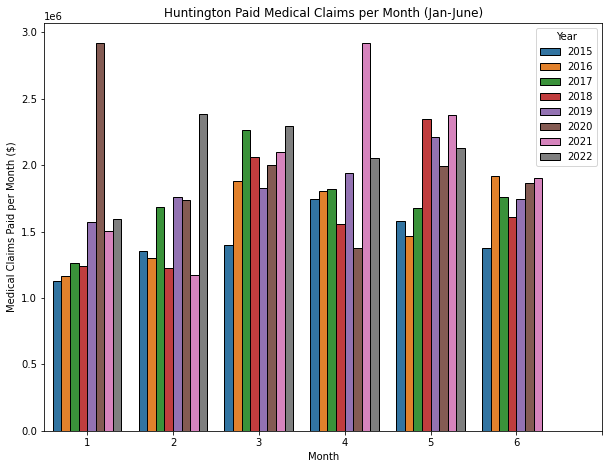

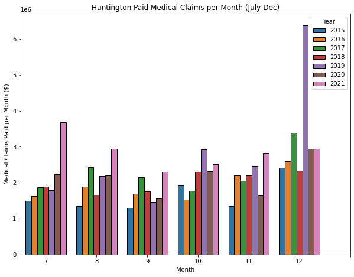

```python
# Visualizing Total Medical Paid Claims by Month
plt.figure(figsize=(10, 7.5))
sns.barplot(data=claims.query('Month <= 6'), x='Month', y='Total Medical Claims', hue='Year')
plt.ylabel('Medical Claims Paid per Month ($)')
plt.xticks(np.arange(0, 7))
plt.title('Huntington Paid Medical Claims per Month (Jan-June)')
plt.show()

plt.figure(figsize=(10, 7.5))
sns.barplot(data=claims.query('Month > 6'), x='Month', y='Total Medical Claims', hue='Year')
plt.ylabel('Medical Claims Paid per Month ($)')
plt.xticks(np.arange(0, 7))
plt.title('Huntington Paid Medical Claims per Month (July-Dec)')
plt.show()
```

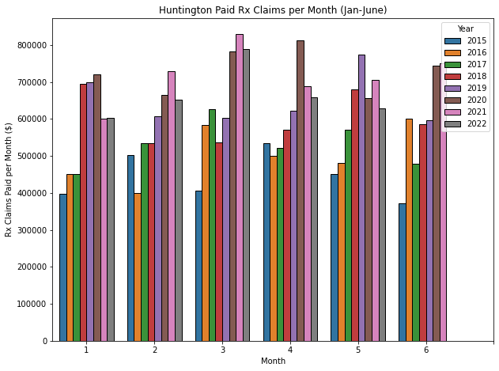

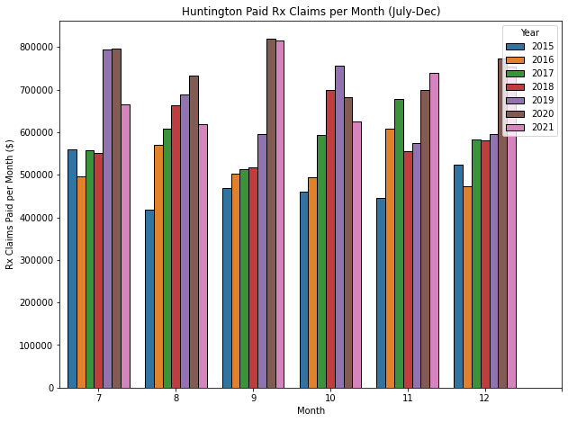

```python
# Visualizing Total Rx Claims
plt.figure(figsize=(10, 7.5))
sns.barplot(data=claims.query('Month <= 6'), x='Month', y='Rx Claims', hue='Year')
plt.ylabel('Rx Claims Paid per Month ($)')
plt.xticks(np.arange(0, 7))
plt.title('Huntington Paid Rx Claims per Month (Jan-June)')
plt.show()

plt.figure(figsize=(10, 7.5))
sns.barplot(data=claims.query('Month > 6'), x='Month', y='Rx Claims', hue='Year')
plt.ylabel('Rx Claims Paid per Month ($)')
plt.xticks(np.arange(0, 7))
plt.title('Huntington Paid Rx Claims per Month (July-Dec)')
plt.show()
```

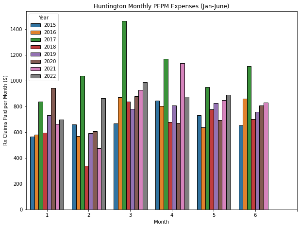

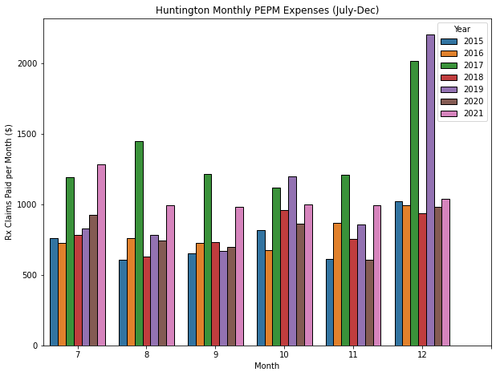

```python
# Visualizing MONTHLY PMPM expenses
plt.figure(figsize=(10, 7.5))
sns.barplot(data=claims.query('Month <= 6'), x='Month', y='PEPM', hue='Year')
plt.ylabel('Rx Claims Paid per Month ($)')
plt.xticks(np.arange(0, 7))
plt.title('Huntington Monthly PEPM Expenses (Jan-June)')
plt.show()

plt.figure(figsize=(10, 7.5))
sns.barplot(data=claims.query('Month > 6'), x='Month', y='PEPM', hue='Year')
plt.ylabel('Rx Claims Paid per Month ($)')
plt.xticks(np.arange(0, 7))
plt.title('Huntington Monthly PEPM Expenses (July-Dec)')
plt.show()
```

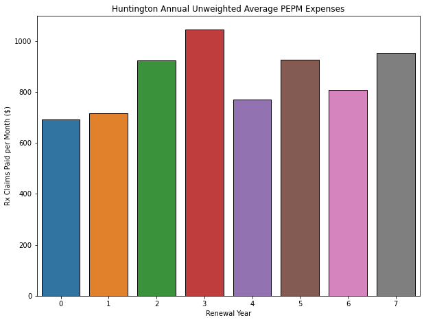

```python
# Visualizing YEARLY PMPM expenses
plt.figure(figsize=(10, 7.5))
sns.barplot(data=claims.groupby('Renewal Year').mean().reset_index(), x='Renewal Year', y='PEPM')
plt.ylabel('Rx Claims Paid per Month ($)')
plt.title('Huntington Annual Unweighted Average PEPM Expenses')
plt.show()
```

*Note: The values in the plot above are unweighted averages as they do not weight each month's PEPM expense by the proportion of Employee Months that are accrued. However, the EE Count remains relatively stable throughout and thus does not actually affect the overall shape of the plot.*

Let's breakdown these plots. The first two barplots visualize monthly Medical Claims paid by Year. Looking at these, we see one major takeaway:

- There appear to be some major outlying months (most obviously 1/20, 2/22, 4/21, 7/21, 12/19)

While this is interesting, it isn't really all that important since we really should be focusing on PMPM or PEPM values.  
The second two barplots are nearly identical to the first two except that they visualize **Rx Claims**. Unsurprisingly, we see some similar trends:

- Values from more recent years seem abnormally high

Like before, this isn't really all that important. The next three plots are much more important as far as this project is concerned. The next two plots visualize Huntington Monthly PEPM Expenses by Year. Like the first four plots, there are certain months which are clearly outliers (most notably 2/17, 2/18, 3/17, 4/17, 4/18, 4/21, 5/17, 6/17, 7/17, 8/17, 9/17, 11/17, 12/17, and 12/19). Since we'll be wanting to Bootstrap using these values, we'll need to replace these outlier values. Below, we will be replacing these values with the average PEPM value between the PEPM expense for the same month of the previous year and the PEPM expense of the same month for the next year. **Should one of the outliers fall in the first or last year in the data, it will not be replaced**. For now, we will manually remove the outliers on Excel and reload the dataset back in.

```python
stripped_claims = pd.read_csv('Huntington Medical Paid Claims Data Outlier Removed.csv')
stripped_claims
```

|  | Month | Year | Renewal Year | Domestic Medical Claims | Non-Domestic Medical Claims | Total Hospital Medical Claims | Non-Hospital Medical Claims | Total Medical Claims | Rx Claims | Rx Rebates | Rx Performance Guarantee | Stop Loss Reimbursement | Adjusted Paid Claims | Member Count | EE Count | PEPM |
| --- | --- | --- | --- | --- | --- | --- | --- | --- | --- | --- | --- | --- | --- | --- | --- | --- |
| 0 | 1 | 2015 | 0 | 414313.73 | 324468.71 | 738782.44 | 385900.53 | 1124682.97 | 397849.95 | 0.00 | 0.00 | 0.0 | 1522532.92 | 6146 | 2690 | 565.997368 |
| 1 | 2 | 2015 | 0 | 539505.55 | 307763.94 | 847269.49 | 507899.40 | 1355168.89 | 503271.97 | 67540.50 | 0.00 | 0.0 | 1790900.36 | 6111 | 2716 | 659.388940 |
| 2 | 3 | 2015 | 0 | 582799.17 | 272127.91 | 854927.08 | 539969.58 | 1394896.66 | 406481.14 | 0.00 | 0.00 | 0.0 | 1801377.80 | 6133 | 2706 | 665.697635 |
| 3 | 4 | 2015 | 0 | 894533.91 | 253610.74 | 1148144.65 | 593447.65 | 1741592.30 | 533681.67 | 0.00 | 0.00 | 0.0 | 2275273.97 | 6113 | 2699 | 843.006287 |
| 4 | 5 | 2015 | 0 | 732374.57 | 424912.54 | 1157287.11 | 419625.09 | 1576912.20 | 451070.89 | 66067.50 | 0.00 | 0.0 | 1961915.59 | 6114 | 2683 | 731.239504 |
| ... | ... | ... | ... | ... | ... | ... | ... | ... | ... | ... | ... | ... | ... | ... | ... | ... |
| 84 | 1 | 2022 | 7 | 501463.78 | 474951.54 | 976415.32 | 619224.78 | 1595640.10 | 603637.45 | 0.00 | 0.00 | 0.0 | 2199277.55 | 6622 | 3145 | 699.293339 |
| 85 | 2 | 2022 | 7 | 702513.46 | 541335.00 | 1243848.46 | 1140214.23 | 2384062.69 | 650981.28 | 370485.73 | 0.00 | 0.0 | 2664558.24 | 6612 | 3092 | 861.758810 |
| 86 | 3 | 2022 | 7 | 760937.71 | 588458.73 | 1349396.44 | 943089.50 | 2292485.94 | 788584.54 | 0.00 | 11435.00 | 0.0 | 3069635.48 | 6643 | 3111 | 986.703787 |
| 87 | 4 | 2022 | 7 | 579591.91 | 513879.57 | 1093471.48 | 963612.60 | 2057084.08 | 659029.75 | 0.00 | 0.00 | 0.0 | 2716113.83 | 6588 | 3108 | 873.910499 |
| 88 | 5 | 2022 | 7 | 462605.24 | 651661.71 | 1114266.95 | 1016179.46 | 2130446.41 | 627878.54 | 0.00 | 11250.05 | 0.0 | 2747074.90 | 6618 | 3093 | 888.158713 |

89 rows × 16 columns

Now let's recreate the visualizations from before:

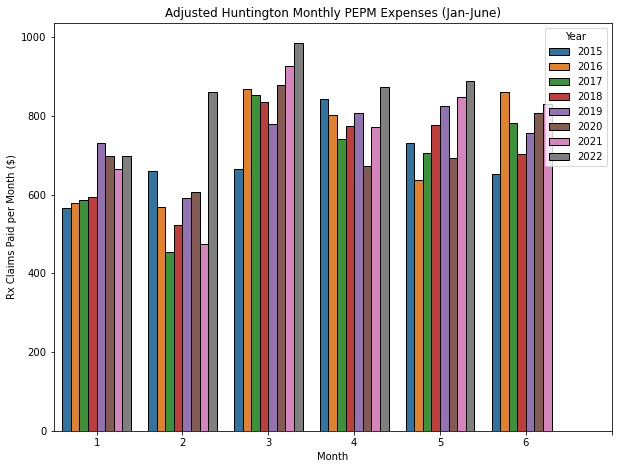

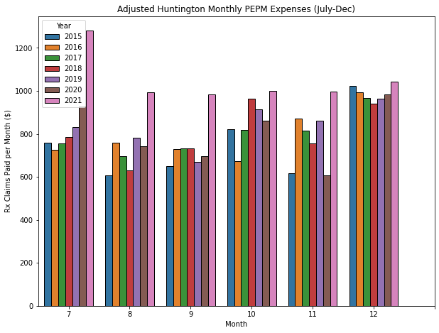

```python
# Visualizing MONTHLY PMPM expenses
plt.figure(figsize=(10, 7.5))
sns.barplot(data=stripped_claims.query('Month <= 6'), x='Month', y='PEPM', hue='Year')
plt.ylabel('Rx Claims Paid per Month ($)')
plt.xticks(np.arange(0, 7))
plt.title('Adjusted Huntington Monthly PEPM Expenses (Jan-June)')
plt.show()

plt.figure(figsize=(10, 7.5))
sns.barplot(data=stripped_claims.query('Month > 6'), x='Month', y='PEPM', hue='Year')
plt.ylabel('Rx Claims Paid per Month ($)')
plt.xticks(np.arange(0, 7))
plt.title('Adjusted Huntington Monthly PEPM Expenses (July-Dec)')
plt.show()
```

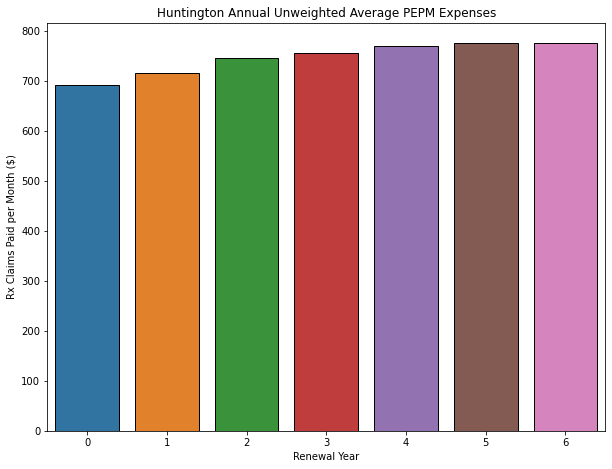

```python
# Visualizing YEARLY PMPM expenses
plt.figure(figsize=(10, 7.5))
sns.barplot(data=stripped_claims.query('`Renewal Year` != 7').groupby('Renewal Year').mean().reset_index(), x='Renewal Year', y='PEPM')
plt.ylabel('Rx Claims Paid per Month ($)')
plt.title('Huntington Annual Unweighted Average PEPM Expenses')
plt.show()
```

*Note: The values in the plot above are unweighted averages as they do not weight each month's PEPM expense by the proportion of Employee Months that are accrued. However, the EE Count remains relatively stable throughout and thus does not actually affect the overall shape of the plot.*

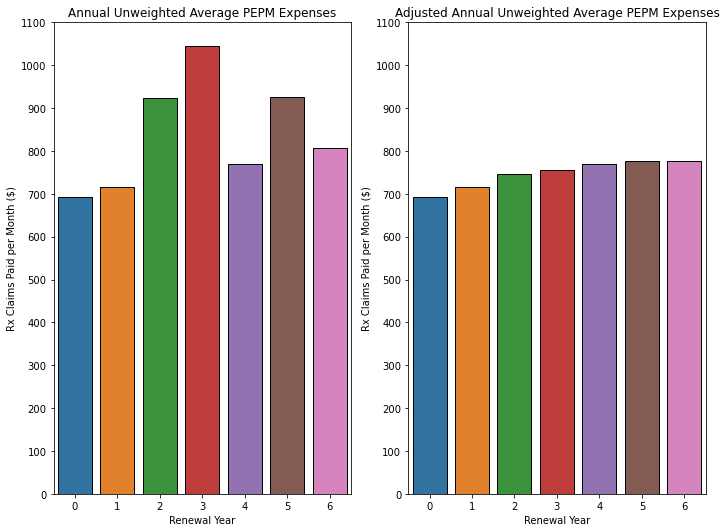

```python
# Side-by-side comparison of actual and adjusted values
plt.figure(figsize=(10, 7.5))
plt.subplot(1, 2, 1)
sns.barplot(data=claims.query('`Renewal Year` != 7').groupby('Renewal Year').mean().reset_index(), x='Renewal Year', y='PEPM')
plt.ylabel('Rx Claims Paid per Month ($)')
plt.yticks(np.arange(0, 1200, 100))
plt.title('Annual Unweighted Average PEPM Expenses')

plt.subplot(1, 2, 2)
sns.barplot(data=stripped_claims.query('`Renewal Year` != 7').groupby('Renewal Year').mean().reset_index(), x='Renewal Year', y='PEPM')
plt.ylabel('Rx Claims Paid per Month ($)')
plt.yticks(np.arange(0, 1200, 100))
plt.title('Adjusted Annual Unweighted Average PEPM Expenses')
plt.tight_layout()
plt.show()
```

The plot to the right look much better, we'll go ahead and use this fixed up data (`stripped_claims`) to train our model.

```python
stripped_claims
```

|  | Month | Year | Renewal Year | Domestic Medical Claims | Non-Domestic Medical Claims | Total Hospital Medical Claims | Non-Hospital Medical Claims | Total Medical Claims | Rx Claims | Rx Rebates | Rx Performance Guarantee | Stop Loss Reimbursement | Adjusted Paid Claims | Member Count | EE Count | PEPM |
| --- | --- | --- | --- | --- | --- | --- | --- | --- | --- | --- | --- | --- | --- | --- | --- | --- |
| 0 | 1 | 2015 | 0 | 414313.73 | 324468.71 | 738782.44 | 385900.53 | 1124682.97 | 397849.95 | 0.00 | 0.00 | 0.0 | 1522532.92 | 6146 | 2690 | 565.997368 |
| 1 | 2 | 2015 | 0 | 539505.55 | 307763.94 | 847269.49 | 507899.40 | 1355168.89 | 503271.97 | 67540.50 | 0.00 | 0.0 | 1790900.36 | 6111 | 2716 | 659.388940 |
| 2 | 3 | 2015 | 0 | 582799.17 | 272127.91 | 854927.08 | 539969.58 | 1394896.66 | 406481.14 | 0.00 | 0.00 | 0.0 | 1801377.80 | 6133 | 2706 | 665.697635 |
| 3 | 4 | 2015 | 0 | 894533.91 | 253610.74 | 1148144.65 | 593447.65 | 1741592.30 | 533681.67 | 0.00 | 0.00 | 0.0 | 2275273.97 | 6113 | 2699 | 843.006287 |
| 4 | 5 | 2015 | 0 | 732374.57 | 424912.54 | 1157287.11 | 419625.09 | 1576912.20 | 451070.89 | 66067.50 | 0.00 | 0.0 | 1961915.59 | 6114 | 2683 | 731.239504 |
| ... | ... | ... | ... | ... | ... | ... | ... | ... | ... | ... | ... | ... | ... | ... | ... | ... |
| 84 | 1 | 2022 | 7 | 501463.78 | 474951.54 | 976415.32 | 619224.78 | 1595640.10 | 603637.45 | 0.00 | 0.00 | 0.0 | 2199277.55 | 6622 | 3145 | 699.293339 |
| 85 | 2 | 2022 | 7 | 702513.46 | 541335.00 | 1243848.46 | 1140214.23 | 2384062.69 | 650981.28 | 370485.73 | 0.00 | 0.0 | 2664558.24 | 6612 | 3092 | 861.758810 |
| 86 | 3 | 2022 | 7 | 760937.71 | 588458.73 | 1349396.44 | 943089.50 | 2292485.94 | 788584.54 | 0.00 | 11435.00 | 0.0 | 3069635.48 | 6643 | 3111 | 986.703787 |
| 87 | 4 | 2022 | 7 | 579591.91 | 513879.57 | 1093471.48 | 963612.60 | 2057084.08 | 659029.75 | 0.00 | 0.00 | 0.0 | 2716113.83 | 6588 | 3108 | 873.910499 |
| 88 | 5 | 2022 | 7 | 462605.24 | 651661.71 | 1114266.95 | 1016179.46 | 2130446.41 | 627878.54 | 0.00 | 11250.05 | 0.0 | 2747074.90 | 6618 | 3093 | 888.158713 |

89 rows × 16 columns

```python
stripped_claims[['EE Count', 'PEPM']]
```

|  | EE Count | PEPM |
| --- | --- | --- |
| 0 | 2690 | 565.997368 |
| 1 | 2716 | 659.388940 |
| 2 | 2706 | 665.697635 |
| 3 | 2699 | 843.006287 |
| 4 | 2683 | 731.239504 |
| ... | ... | ... |
| 84 | 3145 | 699.293339 |
| 85 | 3092 | 861.758810 |
| 86 | 3111 | 986.703787 |
| 87 | 3108 | 873.910499 |
| 88 | 3093 | 888.158713 |

89 rows × 2 columns

## Model Creation

Now that we've created a more representative dataset, we'll use it to train our model. Before we begin any actual programming, let's lay out a high level overview of the process we'll be following:

1. Generate 100 resamples per month
2. Strip resampled DataFrame to include just Month, Year, Renewal Year, and PEPM

```python
# Generating resamples
resampled_months = pd.DataFrame(columns=['Month',
                                         'Year'])
for num in np.arange(1, 13):
    for i in np.arange(100):
        each_month = stripped_claims.query('Month == @num')
        month = [num, num, num, num, num, num, num]
        year = [2015, 2016, 2017, 2018, 2019, 2020, 2021]
        df = {'Month': month, 'Year': year}
        resampled = pd.DataFrame(data=df)
        resample = each_month[['EE Count', 'PEPM']].sample(frac=1, replace=True, axis=0).reset_index().drop('index', axis=1)
        resampled['EE Count'] = resample['EE Count']
        resampled['PEPM'] = resample['PEPM']
        resampled_months = resampled_months.append(resampled)
resampled_months = resampled_months.reset_index().drop('index', axis=1).dropna()

# Further data transformations
def add_renewal_year(month, year):
    '''
    Function that returns a list of the corresponding Renewal Year for Huntington Medical Group
    -----
    Inputs:

    month (Python list) - Month column in resampled_months DataFrame

    year (Python list) - Year column in resampled_months DataFrame
    -----
    Output:

    renewal_year (Python list) - Corresponding renewal year column to be added to the
                                 resampled_months DataFrame
    '''
    renewal_year = []
    for i in np.arange(0, len(month)):
        if month[i] <= 5 and year[i] == 2015:
            renewal_year.append(0)
        elif month[i] >= 6 and year[i] == 2015:
            renewal_year.append(1)
        elif month[i] <=5 and year[i] == 2016:
            renewal_year.append(1)
        elif month[i] >= 6 and year[i] == 2016:
            renewal_year.append(2)
        elif month[i] <= 5 and year[i] == 2017:
            renewal_year.append(2)
        elif month[i] >= 6 and year[i] == 2017:
            renewal_year.append(3)
        elif month[i] <= 5 and year[i] == 2018:
            renewal_year.append(3)
        elif month[i] >= 6 and year[i] == 2018:
            renewal_year.append(4)
        elif month[i] <= 5 and year[i] == 2019:
            renewal_year.append(4)
        elif month[i] >= 6 and year[i] == 2019:
            renewal_year.append(5)
        elif month[i] <= 5 and year[i] == 2020:
            renewal_year.append(5)
        elif month[i] >= 6 and year[i] == 2020:
            renewal_year.append(6)
        elif month[i] <= 5 and year[i] == 2021:
            renewal_year.append(6)
        elif month[i] >= 6 and year[i] == 2021:
            renewal_year.append(7)
        elif month[i] <= 5 and year[i] == 2022:
            renewal_year.append(7)
        else:
            renewal_year.append(10)
    return renewal_year
resampled_months['Renewal Year'] = add_renewal_year(resampled_months['Month'].values, \
                                                    resampled_months['Year'].values)
resampled_months
```

|  | Month | Year | EE Count | PEPM | Renewal Year |
| --- | --- | --- | --- | --- | --- |
| 0 | 1 | 2015 | 3145.0 | 699.293339 | 0 |
| 1 | 1 | 2016 | 2781.0 | 579.693833 | 1 |
| 2 | 1 | 2017 | 3108.0 | 731.653214 | 2 |
| 3 | 1 | 2018 | 3145.0 | 699.293339 | 3 |
| 4 | 1 | 2019 | 3164.0 | 697.991813 | 4 |
| ... | ... | ... | ... | ... | ... |
| 8395 | 12 | 2017 | 2711.0 | 1021.661951 | 3 |
| 8396 | 12 | 2018 | 3055.0 | 962.650276 | 4 |
| 8397 | 12 | 2019 | 3160.0 | 985.160269 | 5 |
| 8398 | 12 | 2020 | 3055.0 | 962.650276 | 6 |
| 8399 | 12 | 2021 | 3001.0 | 991.919943 | 7 |

8400 rows × 5 columns

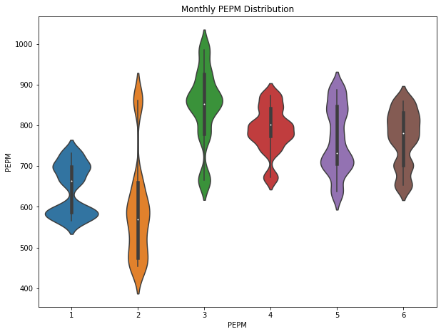

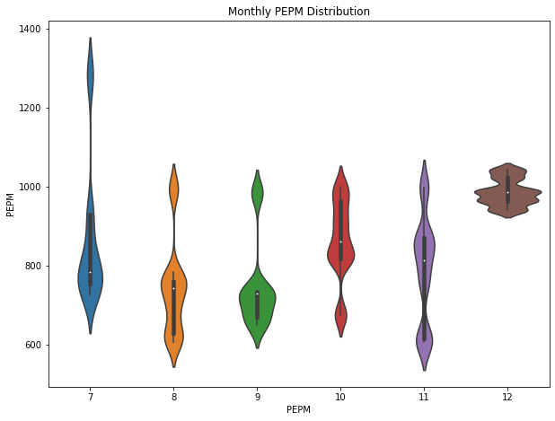

```python
# Violin plots for January-June
plt.figure(figsize=(10, 7.5))
sns.violinplot(data=resampled_months.query('Month <= 6'), x='Month', y='PEPM')
plt.xlabel('PEPM')
plt.title('Monthly PEPM Distribution')
plt.show()

# Violin plots for July-December
plt.figure(figsize=(10, 7.5))
sns.violinplot(data=resampled_months.query('Month > 6'), x='Month', y='PEPM')
plt.xlabel('PEPM')
plt.title('Monthly PEPM Distribution')
plt.show()
```

## Unfinished -- Ignore all below

Before we actually get started with the data wrangling/bootstrapping process, I think it is worth noting, again, that because we are training this model with data specifically from Huntington Hospital, we can really only say its predictions are valid for Huntington Hospital. That is not to say that its predictions aren't necessarily generalizable, but it take more rigorous testing to determine the extent to which this particular model will work for different clients.

```python
resampled = stripped_claims.query('Month == 1').sample(frac=1, replace=True, axis=0)
resampled
```

|  | Month | Year | Renewal Year | Domestic Medical Claims | Non-Domestic Medical Claims | Total Hospital Medical Claims | Non-Hospital Medical Claims | Total Medical Claims | Rx Claims | Rx Rebates | Rx Performance Guarantee | Stop Loss Reimbursement | Adjusted Paid Claims | Member Count | EE Count | PEPM |
| --- | --- | --- | --- | --- | --- | --- | --- | --- | --- | --- | --- | --- | --- | --- | --- | --- |
| 12 | 1 | 2016 | 1 | 469762.84 | 336373.14 | 806135.98 | 356117.04 | 1162253.02 | 449875.53 | 0.0 | 0.0 | 0.0 | 1612128.55 | 6256 | 2781 | 579.693833 |
| 0 | 1 | 2015 | 0 | 414313.73 | 324468.71 | 738782.44 | 385900.53 | 1124682.97 | 397849.95 | 0.0 | 0.0 | 0.0 | 1522532.92 | 6146 | 2690 | 565.997368 |
| 24 | 1 | 2017 | 2 | 420330.71 | 275861.09 | 696191.80 | 567471.93 | 1263663.73 | 451547.90 | 0.0 | 0.0 | 0.0 | 2527327.46 | 6623 | 3020 | 587.191524 |
| 24 | 1 | 2017 | 2 | 420330.71 | 275861.09 | 696191.80 | 567471.93 | 1263663.73 | 451547.90 | 0.0 | 0.0 | 0.0 | 2527327.46 | 6623 | 3020 | 587.191524 |
| 48 | 1 | 2019 | 4 | 683149.70 | 333269.75 | 1016419.45 | 558604.05 | 1575023.50 | 698954.69 | 0.0 | 0.0 | 0.0 | 2273978.19 | 6749 | 3108 | 731.653214 |
| 72 | 1 | 2021 | 6 | 308035.79 | 466745.22 | 774781.01 | 732462.14 | 1507243.15 | 601341.58 | 0.0 | 0.0 | 0.0 | 2108584.73 | 6758 | 3174 | 664.330413 |
| 0 | 1 | 2015 | 0 | 414313.73 | 324468.71 | 738782.44 | 385900.53 | 1124682.97 | 397849.95 | 0.0 | 0.0 | 0.0 | 1522532.92 | 6146 | 2690 | 565.997368 |
| 72 | 1 | 2021 | 6 | 308035.79 | 466745.22 | 774781.01 | 732462.14 | 1507243.15 | 601341.58 | 0.0 | 0.0 | 0.0 | 2108584.73 | 6758 | 3174 | 664.330413 |

```python
# Bootstrapping time!
resampled_months = pd.DataFrame(columns=['Month',
                                         'Year',
                                         'Total Medical Claims',
                                         'Rx Claims',
                                         'Rx Rebates',
                                         'Rx Performance Guarantee',
                                         'Stop Loss Reimbursement',
                                         'Adjusted Paid Claims'])

for num in np.arange(1, 13):
    for i in np.arange(100):
        each_month = stripped_claims.query('Month == @num').loc[:, 'Year':'Stop Loss Reimbursement']
        month = [num, num, num, num, num, num, num, num]
        year = [2015, 2016, 2017, 2018, 2019, 2020, 2021, 2022]
        df = {'Month': month, 'Year': year}
        resampled = pd.DataFrame(data=df)
        for column in each_month.columns[2:]:
            resample = each_month.loc[:, 'Year':column].sample(frac=1, replace=True, axis=0).reset_index().drop('index', axis=1)
            resampled[column] = resample[column]
        #claims_paid = resampled['Total Medical Claims'] \
        #            + resampled['Rx Claims']
        #reimbursements = resampled['Rx Rebates'] \
        #               + resampled['Rx Performance Guarantee'] \
        #               + resampled['Stop Loss Reimbursement']
        #resampled['Adjusted Paid Claims'] = claims_paid - reimbursements
        resampled_months = resampled_months.append(resampled)
resampled_months = resampled_months.reset_index().drop('index', axis=1).dropna()

# Further data transformations
def add_renewal_year(month, year):
    '''
    Function that returns a list of the corresponding Renewal Year for Huntington Medical Group
    -----
    Inputs:

    month (Python list) - Month column in resampled_months DataFrame

    year (Python list) - Year column in resampled_months DataFrame
    -----
    Output:

    renewal_year (Python list) - Corresponding renewal year column to be added to the
                                 resampled_months DataFrame
    '''
    renewal_year = []
    for i in np.arange(0, len(month)):
        if month[i] <= 5 and year[i] == 2015:
            renewal_year.append(0)
        elif month[i] >= 6 and year[i] == 2015:
            renewal_year.append(1)
        elif month[i] <=5 and year[i] == 2016:
            renewal_year.append(1)
        elif month[i] >= 6 and year[i] == 2016:
            renewal_year.append(2)
        elif month[i] <= 5 and year[i] == 2017:
            renewal_year.append(2)
        elif month[i] >= 6 and year[i] == 2017:
            renewal_year.append(3)
        elif month[i] <= 5 and year[i] == 2018:
            renewal_year.append(3)
        elif month[i] >= 6 and year[i] == 2018:
            renewal_year.append(4)
        elif month[i] <= 5 and year[i] == 2019:
            renewal_year.append(4)
        elif month[i] >= 6 and year[i] == 2019:
            renewal_year.append(5)
        elif month[i] <= 5 and year[i] == 2020:
            renewal_year.append(5)
        elif month[i] >= 6 and year[i] == 2020:
            renewal_year.append(6)
        elif month[i] <= 5 and year[i] == 2021:
            renewal_year.append(6)
        elif month[i] >= 6 and year[i] == 2021:
            renewal_year.append(7)
        elif month[i] <= 5 and year[i] == 2022:
            renewal_year.append(7)
        else:
            renewal_year.append(10)
    return renewal_year
resampled_months['Renewal Year'] = add_renewal_year(resampled_months['Month'].values, \
                                                    resampled_months['Year'].values)
resampled_months
```

|  | Month | Year | Total Medical Claims | Rx Claims | Rx Rebates | Rx Performance Guarantee | Stop Loss Reimbursement | Adjusted Paid Claims | Domestic Medical Claims | Non-Domestic Medical Claims | Total Hospital Medical Claims | Non-Hospital Medical Claims | Renewal Year |
| --- | --- | --- | --- | --- | --- | --- | --- | --- | --- | --- | --- | --- | --- |

[figure not shown]

[figure not shown]

```python
# Violin plots for January-June
plt.figure(figsize=(10, 7.5))
sns.violinplot(data=resampled_months.query('Month <= 6'), x='Month', y='PEPM')
plt.xlabel('PEPM')
plt.title('Monthly PEPM Distribution')
plt.show()

# Violin plots for July-December
plt.figure(figsize=(10, 7.5))
sns.violinplot(data=resampled_months.query('Month > 6'), x='Month', y='PEPM')
plt.xlabel('PEPM')
plt.title('Monthly PEPM Distribution')
plt.show()
```

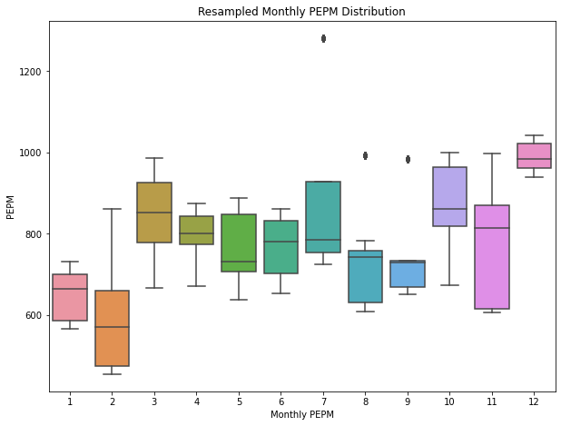

```python
# Boxplot version of the above
plt.figure(figsize=(10, 7.5))
sns.boxplot(data=resampled_months, x='Month', y='PEPM')
plt.xlabel('Monthly PEPM')
plt.title('Resampled Monthly PEPM Distribution')
plt.show()
```

```python
def resampled_yearly_apc(renewal_year, n):
    '''
    Extracts the yearly total Adjusted Paid Claims values from the resampled_months DataFrame
    -----
    Input:

    renewal_year (int) - Int value specifying the renewal year to extract

    n (int) - Number of resamples
    -----
    Output:

    apc_values_ryr (NumPy Array) - NumPy Array of length n (where n is the number of resamples)
                                   with the yearly Adjusted Paid Claims values
    '''
    ryr = resampled_months.sort_values(['Month', 'Year', 'Renewal Year'], ascending=True) \
                          .query('`Renewal Year` == @renewal_year')
    apc_ryr = ryr['Adjusted Paid Claims'].values
    apc_ryr_split = np.split(apc_ryr, 12)
    apc_values_ryr = np.zeros(n)
    for i in np.arange(0, 12):
        apc_values_ryr += apc_ryr_split[i]
    return apc_values_ryr
```

```python
apc_ryr1 = resampled_yearly_apc(1, 100)
apc_ryr2 = resampled_yearly_apc(2, 100)
apc_ryr3 = resampled_yearly_apc(3, 100)
apc_ryr4 = resampled_yearly_apc(4, 100)
apc_ryr5 = resampled_yearly_apc(5, 100)
apc_ryr6 = resampled_yearly_apc(6, 100)
```

Now that we have a bootstrapped dataset, let's look at it and see if it seems to have successfully rebuilt the population.

[figure not shown]

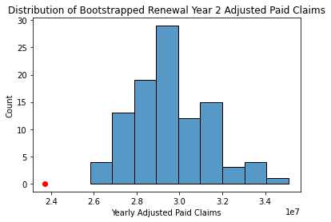

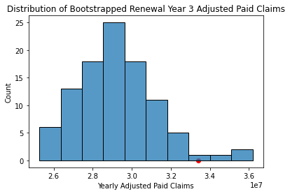

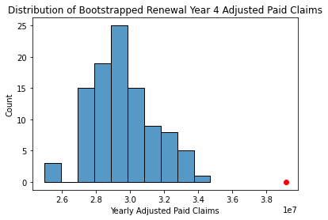

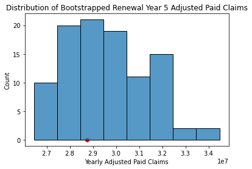

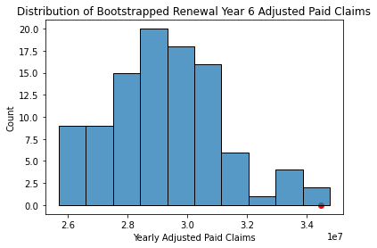

```python
apcs = [apc_ryr1, apc_ryr2, apc_ryr3, apc_ryr4, apc_ryr5, apc_ryr6]
observed_yearly_apcs = claims.groupby('Renewal Year').sum()['Adjusted Paid Claims'].values
i = 0
for apc in apcs:
    observed_year_apc = observed_yearly_apcs[i]
    sns.histplot(data=apc)
    plt.xlabel('Yearly Adjusted Paid Claims')
    plt.title(f'Distribution of Bootstrapped Renewal Year {i + 1} Adjusted Paid Claims')
    plt.scatter(observed_year_apc, -0.01, color='red')
    plt.show()
    i += 1
```

[figure not shown]

```python
sns.histplot()
```

```python
def strip_month_year(month_number, year):
    '''
    Strips Adjusted Paid Claims values for a given month_number and year from resampled_months
    and returns a NumPy array
    -----
    Inputs:

    month_number (int) - Integer corresponding to the month desired

    year (int) - Integer corresponding to the year desired
    -----
    Output:

    month_year (NumPy Array) - Adjusted Paid Claims values from resampled_months corresponding to
                               the month and year specified
    '''
    return resampled_months.query('Month == @month_number and Year == @year')['Adjusted Paid Claims'].values

jan_2015, feb_2015, mar_2015 = [strip_month_year(month_num, 2015) for month_num in np.arange(1, 4)]
apr_2015, may_2015, jun_2015 = [strip_month_year(month_num, 2015) for month_num in np.arange(4, 7)]
jul_2015, aug_2015, sep_2015 = [strip_month_year(month_num, 2015) for month_num in np.arange(7, 10)]
oct_2015, nov_2015, dec_2015 = [strip_month_year(month_num, 2015) for month_num in np.arange(10, 13)]

jan_2016, feb_2016, mar_2016 = [strip_month_year(month_num, 2016) for month_num in np.arange(1, 4)]
apr_2016, may_2016, jun_2016 = [strip_month_year(month_num, 2016) for month_num in np.arange(4, 7)]
jul_2016, aug_2016, sep_2016 = [strip_month_year(month_num, 2016) for month_num in np.arange(7, 10)]
oct_2016, nov_2016, dec_2016 = [strip_month_year(month_num, 2016) for month_num in np.arange(10, 13)]

jan_2017, feb_2017, mar_2017 = [strip_month_year(month_num, 2017) for month_num in np.arange(1, 4)]
apr_2017, may_2017, jun_2017 = [strip_month_year(month_num, 2017) for month_num in np.arange(4, 7)]
jul_2017, aug_2017, sep_2017 = [strip_month_year(month_num, 2017) for month_num in np.arange(7, 10)]
oct_2017, nov_2017, dec_2017 = [strip_month_year(month_num, 2017) for month_num in np.arange(10, 13)]

jan_2018, feb_2018, mar_2018 = [strip_month_year(month_num, 2018) for month_num in np.arange(1, 4)]
apr_2018, may_2018, jun_2018 = [strip_month_year(month_num, 2018) for month_num in np.arange(4, 7)]
jul_2018, aug_2018, sep_2018 = [strip_month_year(month_num, 2018) for month_num in np.arange(7, 10)]
oct_2018, nov_2018, dec_2018 = [strip_month_year(month_num, 2018) for month_num in np.arange(10, 13)]

jan_2019, feb_2019, mar_2019 = [strip_month_year(month_num, 2019) for month_num in np.arange(1, 4)]
apr_2019, may_2019, jun_2019 = [strip_month_year(month_num, 2019) for month_num in np.arange(4, 7)]
jul_2019, aug_2019, sep_2019 = [strip_month_year(month_num, 2019) for month_num in np.arange(7, 10)]
oct_2019, nov_2019, dec_2019 = [strip_month_year(month_num, 2019) for month_num in np.arange(10, 13)]

jan_2020, feb_2020, mar_2020 = [strip_month_year(month_num, 2020) for month_num in np.arange(1, 4)]
apr_2020, may_2020, jun_2020 = [strip_month_year(month_num, 2020) for month_num in np.arange(4, 7)]
jul_2020, aug_2020, sep_2020 = [strip_month_year(month_num, 2020) for month_num in np.arange(7, 10)]
oct_2020, nov_2020, dec_2020 = [strip_month_year(month_num, 2020) for month_num in np.arange(10, 13)]

jan_2021, feb_2021, mar_2021 = [strip_month_year(month_num, 2021) for month_num in np.arange(1, 4)]
apr_2021, may_2021, jun_2021 = [strip_month_year(month_num, 2021) for month_num in np.arange(4, 7)]
jul_2021, aug_2021, sep_2021 = [strip_month_year(month_num, 2021) for month_num in np.arange(7, 10)]
oct_2021, nov_2021, dec_2021 = [strip_month_year(month_num, 2021) for month_num in np.arange(10, 13)]
```

```python
def aggregate_renewal_year(renewal_year):
    '''
    For the specified renewal_year, calculates the Total Adjusted Paid Claims values for
    the 100 resamples
    -----
    Input:

    renewal_year (int) - The specified renewal year (starting with 1 from 6/15-5/16)
    -----
    Outputs:

    renewal_year_totals (NumPy Array) - The Adjusted Paid Values for the 100 resamples
                                        corresponding to the specified renewal_year

    renewal_label (NumPy Array) - NumPy Array consisting of the Renewal Year for inputting
                                  into a DataFrame
    '''
    renewal_label = np.zeros(0)
    if renewal_year == 1:
        renewal_year_totals = jun_2015 + jul_2015 + aug_2015 + sep_2015 + \
                              oct_2015 + nov_2015 + dec_2015 + jan_2016 + \
                              feb_2016 + mar_2016 + apr_2016 + may_2016
    elif renewal_year == 2:
        renewal_year_totals = jun_2016 + jul_2016 + aug_2016 + sep_2016 + \
                              oct_2016 + nov_2016 + dec_2016 + jan_2017 + \
                              feb_2017 + mar_2017 + apr_2017 + may_2017
    elif renewal_year == 3:
        renewal_year_totals = jun_2017 + jul_2017 + aug_2017 + sep_2017 + \
                              oct_2017 + nov_2017 + dec_2017 + jan_2018 + \
                              feb_2018 + mar_2018 + apr_2018 + may_2018
    elif renewal_year == 4:
        renewal_year_totals = jun_2018 + jul_2018 + aug_2018 + sep_2018 + \
                              oct_2018 + nov_2018 + dec_2018 + jan_2019 + \
                              feb_2019 + mar_2019 + apr_2019 + may_2019
    elif renewal_year == 5:
        renewal_year_totals = jun_2019 + jul_2019 + aug_2019 + sep_2019 + \
                              oct_2019 + nov_2019 + dec_2019 + jan_2020 + \
                              feb_2020 + mar_2020 + apr_2020 + may_2020
    elif renewal_year == 6:
        renewal_year_totals = jun_2020 + jul_2020 + aug_2020 + sep_2020 + \
                              oct_2020 + nov_2020 + dec_2020 + jan_2021 + \
                              feb_2021 + mar_2021 + apr_2021 + may_2021
    for i in range(len(renewal_year_totals)):
        renewal_label = np.append(renewal_label, int(renewal_year))
    return renewal_year_totals, renewal_label
```

[output not shown]

```python
resampled_months['Year'].value_counts()
```

```
2020    1200
2019    1200
2018    1200
2017    1200
2016    1200
2015    1200
2021     400
Name: Year, dtype: int64
```

```python
resampled_months['Month'].value_counts()
```

```
4     700
3     700
2     700
1     700
12    600
11    600
10    600
9     600
8     600
7     600
6     600
5     600
Name: Month, dtype: int64
```